# Insecticide Study Analysis

Pascal Bärtschi

2023-08-23

Introduction

Welcome to the analysis of an insecticide study dataset. In this report, we will delve into the data to explore the relationship between mortality and the dose of insecticides, as well as the effects of different insecticide products. Through statistical techniques and visualization, we aim to gain valuable insights from the data.

### Library Imports

Let’s begin by importing the necessary libraries that we’ll be using throughout this analysis. These libraries provide the tools we need for data manipulation, visualization, and statistical modeling.

```r
suppressPackageStartupMessages({
  library("ggplot2")
  library("dplyr")
  library("ggfortify")
  library('tidyverse')
  library('GGally')
  library('MASS')
  library('readr')
})
```

### Data Loading, Exploration and Preprocessing

Before we delve into the analysis, we need to load the dataset and understand its structure. This initial step is crucial in gaining an overview of the data we’ll be working with.

```r
# Load the data
insects <- read.csv('data/new_pesticide_study.csv')

# Display the structure of data and levels of 'product'
glimpse(insects)
```

```
## Rows: 63
## Columns: 5
## $ X       <int> 1, 2, 3, 4, 5, 6, 7, 8, 9, 10, 11, 12, 13, 14, 15, 16, 17, 18,~
## $ product <chr> "A", "A", "A", "A", "A", "A", "A", "A", "A", "A", "A", "A", "A~
## $ logdose <dbl> -5.0, -4.5, -4.0, -3.5, -3.0, -2.5, -2.0, -1.5, -1.0, -0.5, 0.~
## $ n       <int> 9, 10, 12, 14, 9, 14, 14, 12, 12, 8, 9, 9, 12, 10, 13, 11, 13,~
## $ dead    <int> 0, 0, 0, 0, 1, 0, 3, 2, 5, 3, 6, 6, 8, 8, 12, 10, 11, 14, 10, ~
```

```r
levels(insects$product)
```

[output not shown]

Next, we compute new measures of the data:

```r
# new frame where trials and dead expressed in success/failure
insects <- mutate(insects, successes = dead,
                  failures = n-dead)

# add success proportion
insects <- mutate(insects, proportion_success = successes/n)
```

### Visualizing Mortality and Dose Relationship

To gain an initial understanding of the data, we’ll visualize the relationship between mortality and the dose of insecticides. Additionally, we’ll examine how different insecticide products influence this relationship.

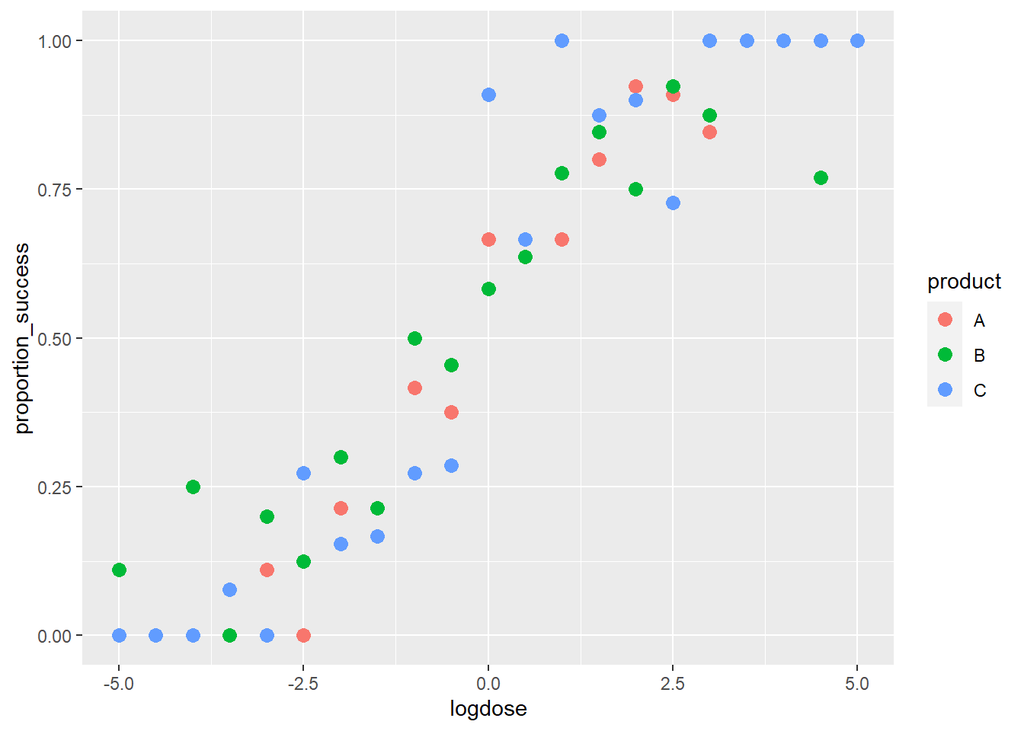

```r
# Visualize the relationship between mortality and dose of insecticides
# as well as the effects of different products
ggplot(insects, aes(x = logdose, y = proportion_success,
                    colour = product)) +
  geom_point(size = 3)
```

### Incorrect Linear Model

Our initial attempt involves fitting a linear model to the data, trying to capture the relationship between mortality and dose. However, this approach might not be the most suitable for the nature of the data.

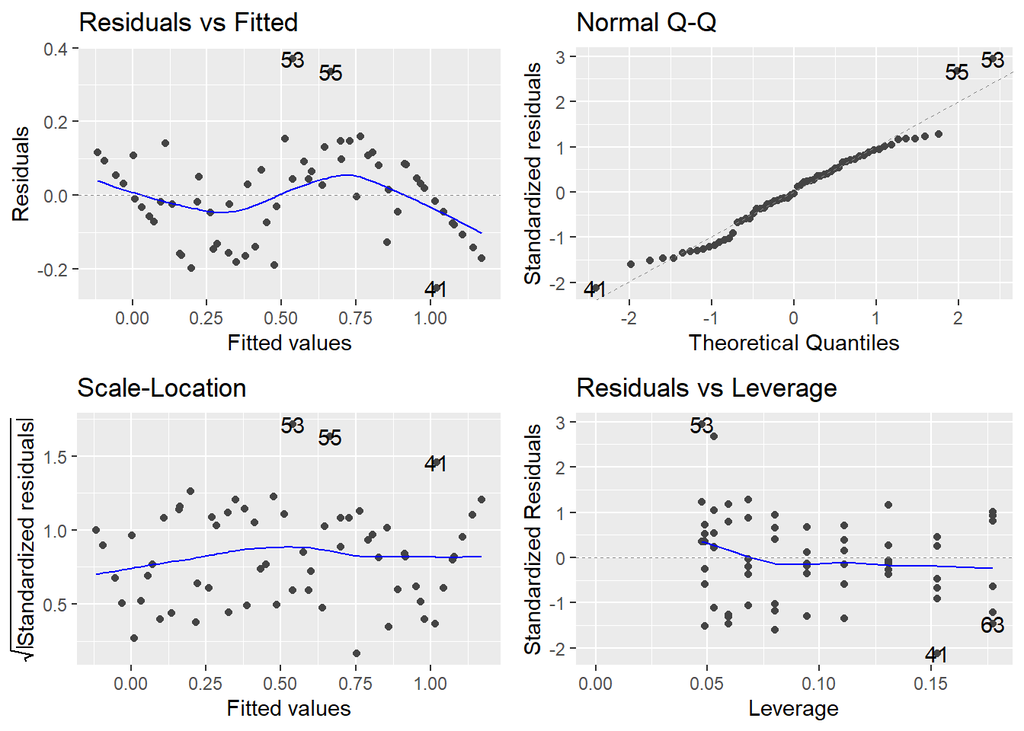

```r
# Fit a linear model (incorrect approach)
m1 <- lm(proportion_success ~ logdose * product, data = insects)
autoplot(m1)
```

### Correct Approach with Binomial Regression

To accurately model the relationship between mortality and dose, we need to consider the binomial distribution of the response variable. This involves using a binomial regression approach that takes into account the binary nature of the data.

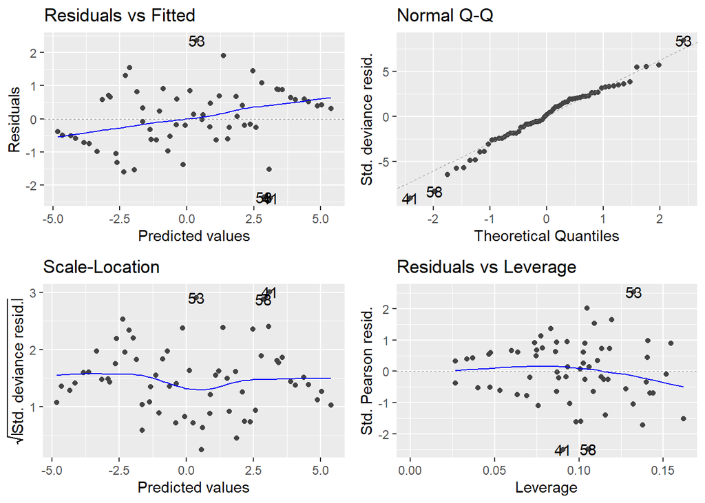

```r
# Set up the binomial regression model
glm1 <- glm(cbind(successes, failures) ~ logdose * product,
            data = insects, family = binomial)

# Diagnostic plot
autoplot(glm1, smooth.color = NA)
```

### Deviance and Interaction

Deviance analysis helps us assess the goodness of fit of the model. We’ll perform a chi-squared test for interaction terms to evaluate whether the different insecticide products have varying effects on the mortality-dose relationship.

```r
# Explore deviance and test for interaction
anova(glm1, test = 'Chisq')
```

```
## Analysis of Deviance Table
##
## Model: binomial, link: logit
##
## Response: cbind(successes, failures)
##
## Terms added sequentially (first to last)
##
##
##                 Df Deviance Resid. Df Resid. Dev Pr(>Chi)
## NULL                               62     541.46
## logdose          1   475.91        61      65.55  < 2e-16 ***
## product          2     0.71        59      64.85  0.70131
## logdose:product  2     9.19        57      55.65  0.01009 *
## ---
## Signif. codes:  0 '***' 0.001 '**' 0.01 '*' 0.05 '.' 0.1 ' ' 1
```

### Biological Interpretation

Before diving deeper, it’s important to interpret the results in a biologically meaningful way. Visualization aids us in understanding the implications of the statistical findings.

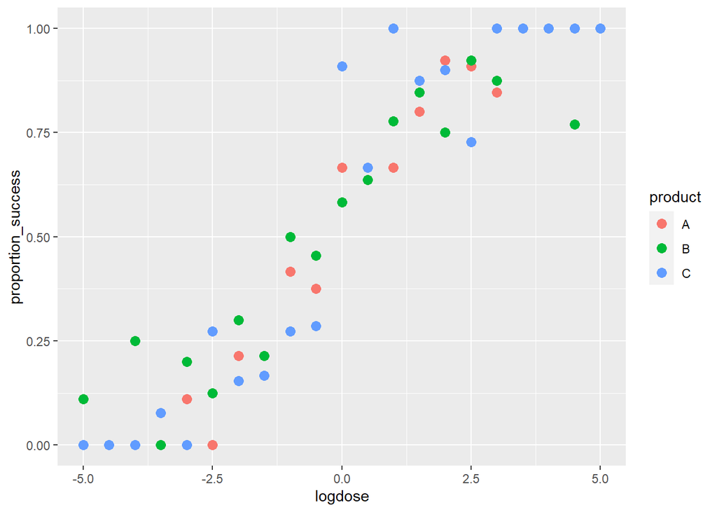

```r
# Plot for biological interpretation
ggplot(insects, aes(x = logdose, y = proportion_success,
                    colour = product)) +
  geom_point(size = 3)
```

### Model Summary and Interpretation

```r
# Model summary and interpretation
summary(glm1)
```

```
##
## Call:
## glm(formula = cbind(successes, failures) ~ logdose * product,
##     family = binomial, data = insects)
##
## Deviance Residuals:
##      Min        1Q    Median        3Q       Max
## -2.39568  -0.60044   0.07022   0.64900   2.36789
##
## Coefficients:
##                  Estimate Std. Error z value Pr(>|z|)
## (Intercept)       0.10953    0.21497   0.510   0.6104
## logdose           0.98622    0.11835   8.333   <2e-16 ***
## productB          0.14427    0.27899   0.517   0.6051
## productC          0.25828    0.30986   0.834   0.4045
## logdose:productB -0.35196    0.14265  -2.467   0.0136 *
## logdose:productC  0.01627    0.17436   0.093   0.9257
## ---
## Signif. codes:  0 '***' 0.001 '**' 0.01 '*' 0.05 '.' 0.1 ' ' 1
##
## (Dispersion parameter for binomial family taken to be 1)
##
##     Null deviance: 541.462  on 62  degrees of freedom
## Residual deviance:  55.652  on 57  degrees of freedom
## AIC: 162.38
##
## Number of Fisher Scoring iterations: 5
```

### Predictions and Visualization

With the model in place, we can make predictions about the relationship between mortality and dose for different insecticide products. This allows us to visualize the predicted trends and assess the effects of each product.

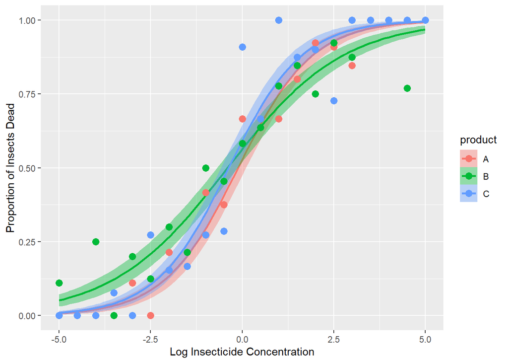

```r
# Create new dataset for predictions
new_data <- expand.grid(logdose = seq(min(insects$logdose),
                                      max(insects$logdose),
                                      length = 100),
                        product = unique(insects$product))

# Predict and visualize
p1 <- predict(glm1, newdata = new_data, se.fit = TRUE,
              type = 'response')
n1 <- cbind(new_data, p1)

ggplot(insects, aes(x = logdose, y = proportion_success,
                    colour = product)) +
  geom_smooth(data = n1, mapping = aes(x = logdose, y = fit,
                                       ymin = fit - se.fit,
                                       ymax = fit + se.fit,
                                       fill = product),
              stat = 'identity') +
  geom_point(size = 3) +
  xlab('Log Insecticide Concentration') +
  ylab('Proportion of Insects Dead')
```

Conclusion

This analysis has provided insights into the relationship between mortality and the dose of insecticides, as well as the varying effects of different insecticide products. By employing proper statistical techniques and visualization methods, we’ve gained a deeper understanding of the data and its implications.